# 꺼지지 않는 스위치

판단 점수의 꼬리 두께가 자동화의 경계를 정한다 — 반도체 소자물리(스위칭 특성) × 정보이론(결정 정보) × 조직설계(위임 가능성)

저자

Insight Lab × Claude

공개

2026년 9월 27일

**노트핵심 문장**

자동화의 경계는 모델이 얼마나 정확한가가 아니라 **얼마나 끝까지 가는가**로 정해진다. 판단 점수의 꼬리 두께를 재 보니 과제의 사실성에 비례했고, 취향을 묻는 질문에서는 **정확히 0%**였다 — 게이트 전압을 흔들어도 전류가 변하지 않는 소자와 같다. 그런데 꼬리가 두꺼운 과제는 이미 정규식으로 해결된다. 그래서 값싼 판단이 실제로 일을 대신할 수 있는 구간은 **“규칙으로는 안 되고 취향은 아닌” 좁은 띠**뿐이다.

# 1 평균 정확도는 소자 사양이 아니다

트랜지스터를 살 때 “평균 전류”를 보고 고르는 사람은 없다. 보는 것은 두 가지다. **온·오프 전류비**가 얼마인지, 그리고 게이트 전압을 조금 흔들었을 때 전류가 몇 자리수 변하는지(**서브스레숄드 스윙**, mV/decade)다.

이유는 간단하다. 스위치의 쓸모는 세기가 아니라 **확실히 꺼지는가**에 있다. 평균 전류가 아무리 좋아도 완전히 꺼지지 않는 소자는 누설로 회로를 망친다.

판단을 파는 모델에도 같은 질문을 해야 한다. 그런데 우리는 습관적으로 평균만 본다. “정확도 80%”는 소자 사양이 아니다. 필요한 건 이것이다.

> 이 모델은 **얼마나 자주 확실해지는가.**

이 글은 그것을 실측한다. 재는 대상은 앞선 편(SP25)에서 다룬 판단 전용 모델 Jev(TypeSafe AI, 입력 100만 토큰 0.042달러·출력 무료)다. 물어본 내용은 다르다. SP25는 “맞히는가”를 물었고, 이 글은 **“확실해지는가”**를 묻는다.

# 2 게이트 구조가 요구하는 것

값싼 판단을 실무에 넣는 가장 자연스러운 설계는 문턱 두 개를 세우는 것이다.

```
점수 ≤ 0.10  →  자동으로 아니라고 처리
점수 ≥ 0.90  →  자동으로 그렇다고 처리
그 사이       →  비싼 추론 모델(또는 사람)에게 넘긴다
```

디지털 회로의 논리 레벨과 같은 구조다. 확실한 구간만 자동으로 흘리고 중간 전압은 버린다. 이 설계의 경제성은 하나의 숫자에 전부 달려 있다.

> **자동 구간에 몇 %가 들어오는가.**

10%만 들어오면 90%를 여전히 비싼 모델에 보내면서 값싼 모델 비용까지 더 내는 것이다. 순수 손실이다. 그래서 게이트를 설계하기 전에 **꼬리 두께**를 재야 한다. 정확도보다 먼저 재야 한다.

# 3 측정 1 — 메일 판단에서는 꼬리가 없었다

먼저 SP25에서 쓴 실측 자료를 다시 본다. 실제 받은 메일 120건(정상 60·스팸 60)에 “이것은 원치 않은 대량 광고·사기인가”를 물어 확률을 받았다.

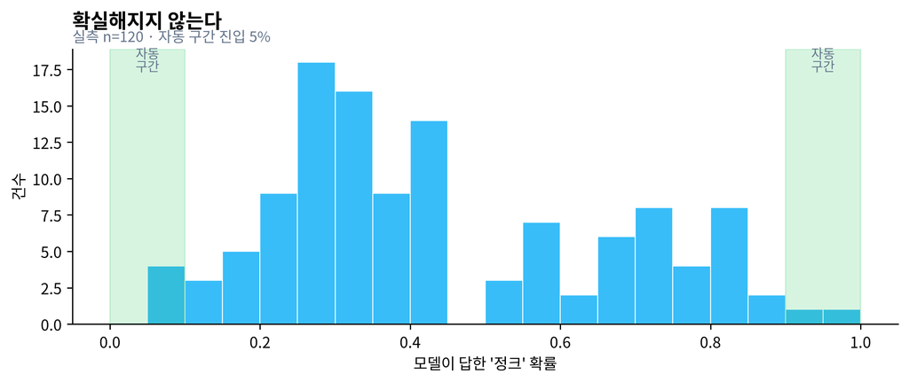

그림 1: 메일 판단 확률의 분포(실측 120건). 0과 1 근처가 비어 있다. 중앙값 0.36, 최소 0.08, 최대 0.98 — 이 소자는 완전히 꺼지지도, 완전히 켜지지도 않는다.

자동 구간에 들어온 것은 **6건, 5%**였다. 그 6건은 오류가 0건이었다 — 확실할 때는 맞았다. 문제는 확실해지는 일이 거의 없었다는 것이다.

## 3.1 문턱을 넓히면 누설이 터진다

커버리지가 부족하면 문턱을 완화하고 싶어진다. 실측 자료로 그 곡선을 그릴 수 있다.

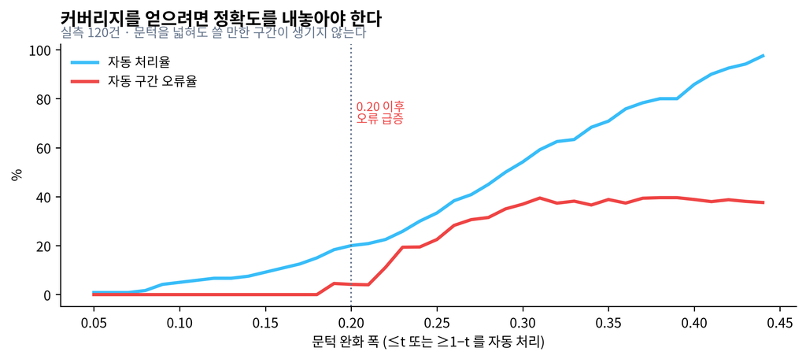

그림 2: 문턱을 완화할 때의 자동 처리율과 자동 구간 오류율(실측 120건). 0.20을 넘기면 오류가 급격히 오른다 — 소자를 문턱 아래로 밀었을 때의 누설 전류 곡선과 같은 모양이다.

0.15까지는 오류가 0인데 자동 처리율이 9%다. 0.20에서 20%·4.2%, 0.25에서 33%·**22.5%**, 0.30에서 54%·36.9%. 절벽이다.

## 3.2 더 나쁜 것 — 점수가 순서를 지키지 않는다

문턱 게이트는 암묵적으로 **점수가 커지면 그럴 확률도 커진다**고 가정한다. 실측은 그 가정을 깨뜨린다.

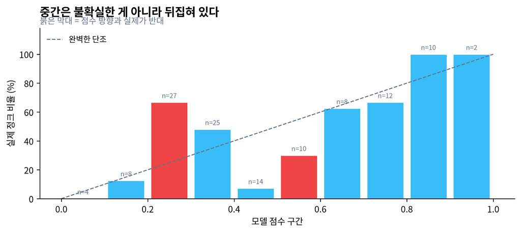

그림 3: 모델 점수 구간별 실제 정크 비율(실측 120건). 단조적이라면 우상향이어야 한다. 0.2~0.3 구간이 67%인데 0.4~0.5 구간은 7%다 — 점수가 순서 자체를 지키지 않는다.

양 끝은 정직하다. 0.8~1.0은 실제 100% 정크고, 0~0.2는 8%다. **중간이 뒤죽박죽이다.** 그래서 문턱을 안쪽으로 밀 때 오류가 선형으로 늘지 않고 절벽처럼 떨어진다. 순서가 없는 구간을 자동 처리에 포함시키는 것이기 때문이다.

# 4 측정 2 — 꼬리 두께는 과제의 성질이다

여기서 자연스러운 의심이 생긴다. 이건 모델의 결함일까, 아니면 **질문의 성질**일까.

“이 메일이 원치 않은 광고인가”는 겉보기에 사실 판단 같지만 실은 그렇지 않다. *누가* 원치 않는지에 답이 달려 있다. 같은 뉴스레터가 어떤 사람에게는 쓰레기고 어떤 사람에게는 구독물이다. 모델은 받는 사람의 취향을 모른다.

그렇다면 취향이 개입하지 않는 질문에서는 꼬리가 두꺼워질 것이다. 이 가설은 **정답 라벨 없이** 검증할 수 있다. 꼬리 두께는 점수 분포의 성질이고, 분포는 정답을 몰라도 관찰된다. 라벨링에 돈을 쓰기 전에 후보를 죽일 수 있다는 뜻이다.

## 4.1 설계

이미 공개된 이 저널의 문단 24개(14편에서 균등 추출, 200~700자)를 코퍼스로 썼다. 공개물이라 유출 위험이 없고, 한 번 호출로 다섯 질문을 동시에 물어 비용을 1/5로 줄였다.

질문은 **사실성의 정도를 달리** 배치했다.

| 질문 | 유형 | 왜 넣었나 |
| --- | --- | --- |
| 숫자가 있는가 | 사실·기계적 | **앵커.** 정규식으로 정답이 공짜다. 이마저 꼬리가 없으면 게이트 자체가 불가능 |
| 방법 서술인가 | 사실·의미적 | 문장을 읽어야 알지만 답은 글 안에 있다 |
| 반대해석이 있는가 | 사실·의미적 | 이 저널의 발행 체크리스트 항목이다 |
| 중요한가 | 선호 | **대조군.** 독자와 필자의 목적에 달려 있다 |
| 줄여야 하는가 | 선호 | **대조군** |

판정 규칙은 **데이터를 보기 전에** 정해 기록했다. 꼬리 40% 이상이면 양방향 게이트를 만들고, 15~40%면 한쪽만 자동화하는 선별검사로 쓰고, 15% 미만이면 기각한다. 이 순서를 지키는 것이 SP25에서 얻은 교훈이다.

## 4.2 결과

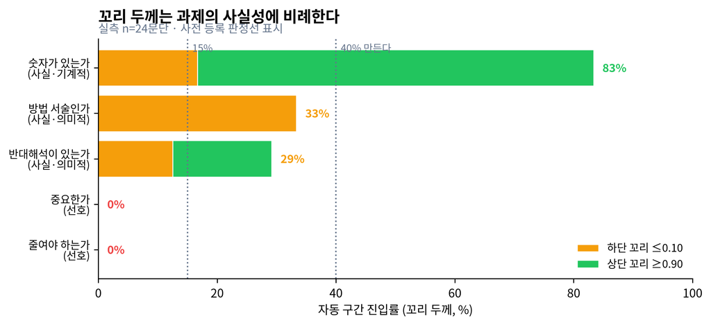

그림 4: 질문 유형별 꼬리 두께(실측 24문단, 질문 5개). 사실성이 높을수록 꼬리가 두껍다. 선호를 묻는 두 질문은 정확히 0%다 — 자동 구간에 단 하나도 들어오지 않았다.

앵커는 통과했다. “숫자가 있는가”는 꼬리 **83%**, 꼬리 구간 오류 **0건**, 전체 일치율 96%였다. 분포는 0.04에서 0.99까지 갔다. 이 모델은 확실해질 능력이 **있다**.

의미적 사실은 중간이었다. “방법 서술인가” 33%, “반대해석이 있는가” 29%.

선호형 두 질문은 **0%**였다. 24문단 중 단 하나도 자동 구간에 들어오지 않았다.

## 4.3 분포를 보면 이유가 보인다

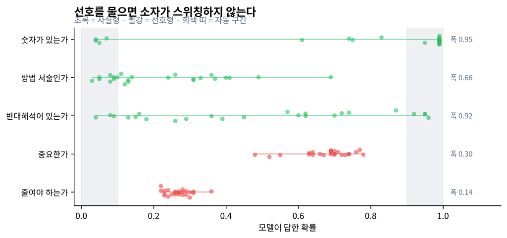

그림 5: 질문별 점수 분포(실측 24문단). 선호형 질문은 폭이 0.30과 0.14에 불과하다. 입력이 바뀌어도 출력이 거의 움직이지 않는다 — 게이트 전압에 반응하지 않는 소자다.

“중요한가”는 0.48~0.78 사이에만 나타난다. “줄여야 하는가”는 0.22~0.36이다. 24개의 서로 다른 문단을 넣었는데 출력이 0.14 폭 안에서만 움직였다. 이것은 불확실한 판단이 아니다. **판단을 하지 않고 있는 것이다.**

소자로 옮기면 이렇다. 게이트 전압을 넓게 흔들었는데 드레인 전류가 한 자리수도 변하지 않는다. 그런 물건은 증폭기로도 스위치로도 쓸 수 없다.

# 5 경계에서 나오는 명제

세 분야가 각각 다른 것을 설명한다. 하나만으로는 답이 안 나온다.

**소자물리**는 무엇을 재야 하는지 알려준다. 평균이 아니라 **온·오프비와 스윙**이다. 그리고 문턱을 완화할 때 오류가 선형이 아니라 지수적으로 늘어나는 이유를 알려준다 — 누설은 원래 그런 모양이다. 측정 1의 절벽은 새로운 현상이 아니라 잘 알려진 곡선이었다.

**정보이론**은 중간에 몰린 분포가 왜 쓸모없는지 설명한다. 엔트로피가 최대에 가까운 점수는 결정 정보를 거의 싣지 않는다. 그리고 단조성 위반은 더 강한 진술이다 — 그 구간에서 점수는 **순서 통계량조차 아니다**. AUC나 임계값 최적화 같은 도구가 전제하는 것이 없다.

**조직설계**는 왜 하필 선호형에서 0%가 나오는지 설명한다. 위임 연구의 오래된 결론은 위임이 **결과를 검증할 수 있을 때만** 작동한다는 것이다. “이 문단이 중요한가”는 위탁한 사람만 검증할 수 있다. 정답이 위탁자의 머릿속에 있으면, 아무리 좋은 대리인도 확신할 근거가 없다. 0%는 모델의 결함이 아니라 **과제가 위임 불가**라는 사실의 측정값이다.

셋을 합치면 경계에서만 나오는 명제가 생긴다.

**중요값싼 판단의 역설, 2단**

**꼬리가 두꺼운 과제는 이미 규칙으로 해결된다. 규칙으로 안 되는 과제는 꼬리가 없다.**

“숫자가 있는가”는 꼬리 83%지만 정규식 한 줄이면 100% 맞힌다 — 모델을 부를 이유가 없다. “이 문단이 중요한가”는 모델이 필요하지만 꼬리가 0%다 — 게이트를 만들 수 없다.

값싼 판단이 실제로 사람 손을 줄이는 구간은 그 사이의 좁은 띠, 이 측정에서는 **꼬리 29~33%의 의미적 사실**뿐이었다.

# 6 그래서 설계는 이렇게 바뀐다

세 가지가 따라 나온다.

**첫째, 도입 판단의 순서를 뒤집는다.** “정확도가 몇 %냐”를 먼저 묻지 않는다. **꼬리가 몇 %냐**를 먼저 묻는다. 꼬리 측정은 정답 라벨이 필요 없어서 라벨링 비용을 쓰기 전에 후보를 탈락시킬 수 있다. 이 글의 측정 2는 24번 호출·2분으로 다섯 후보 중 둘을 죽였다.

**둘째, 양방향 게이트를 한방향 선별검사로 바꾼다.** 꼬리 29%는 양방향 자동화에는 부족하지만, **사람이 볼 목록을 줄이는 데는 충분하다.** “반대해석이 있는가”의 상단 꼬리 17%는 오류 없이 통과 처리할 수 있다. 자동으로 *버리는* 것이 아니라 자동으로 *넘기는* 것이다. 오류 비용이 비대칭일 때는 이쪽만 배선해야 한다.

**셋째, 선호형 판단은 구조적으로 제외한다.** 재시도·프롬프트 수정으로 고쳐질 문제가 아니다. 정답이 사용자 머릿속에 있는 한, 꼬리는 두꺼워지지 않는다. 취향을 자동화하려면 모델을 바꾸는 게 아니라 **취향을 밖으로 꺼내 검증 가능한 규칙으로 적어야** 한다. 그건 모델 도입이 아니라 의사결정 문서화 작업이다.

**경고반대 해석**

**얇은 꼬리는 결함이 아니라 정직함일 수 있다.** 이 글은 꼬리가 없는 것을 한계로 읽었다. 반대로 읽을 수 있다. 사용자의 취향을 모르는 모델이 “중요하다, 확률 0.97”이라고 답한다면 그게 훨씬 위험하다. 0.48~0.78에 머무는 것은 **잘 캘리브레이션된 무지**다. 그 관점에서는 이 모델이 옳게 행동했고, 잘못은 답할 수 없는 것을 물은 쪽에 있다. 실제로 SP25에서 과잉확신이 어떻게 사고로 이어지는지 봤다. 겸손한 소자가 나쁜 소자는 아니다.

**꼬리 두께는 모델 고유값이 아닐 수 있다.** 이 측정은 **제로샷 단일 시점**이다. 사용자의 과거 판정 사례를 예시로 주거나(few-shot), 선호를 학습시키면 선호형 질문에서도 꼬리가 생길 가능성이 있다. 그러면 “선호형은 구조적으로 불가”라는 결론은 “지금 이 설정에서는 불가”로 약해진다. 위임 이론도 같은 것을 말한다 — 검증 기준을 대리인에게 **전달하면** 위임이 가능해진다. 이 글은 그 전달을 하지 않은 상태를 측정했다.

**표본이 작고 좁다.** 측정 2는 n=24문단·모델 1개·코퍼스 1종(한국어 과학 에세이)이다. 꼬리 두께의 신뢰구간은 ±10%p 수준이고, 0%와 33%의 차이는 뚜렷하지만 29%와 33%의 순위는 의미를 두지 말아야 한다. 다른 도메인(코드·의료 기록·법률 문서)에서는 다른 곡선이 나올 수 있다.

**소자 비유의 한계.** 트랜지스터의 서브스레숄드 스윙은 볼츠만 한계라는 물리 하한(약 60 mV/decade)이 있다. 언어모델의 확률 출력에는 그런 하한이 없다. 비유는 *무엇을 재야 하는지*를 알려주는 데까지만 유효하고, *왜 그 값이 나오는지*를 설명하지는 않는다. 누설 곡선의 모양이 닮은 것은 둘 다 문턱 판별 문제이기 때문이고, 같은 물리 때문이 아니다.

# 7 남은 질문

꼬리 두께를 **올릴 수 있는가**가 다음 실험이다. 같은 질문에 사용자의 과거 판정 20건을 예시로 붙이고 꼬리를 다시 재면, 선호형 0%가 움직이는지 볼 수 있다. 움직이면 “취향도 위임 가능하다, 단 기준을 전달했을 때”가 되고, 움직이지 않으면 이 글의 결론이 강해진다. 어느 쪽이든 24번 호출로 답이 나온다.

그리고 더 불편한 질문이 남는다. 꼬리가 두꺼운 일은 규칙으로 되고 규칙으로 안 되는 일은 꼬리가 없다면, **값싼 판단이 늘어난다고 해서 사람의 판단 부담이 줄어드는가.** 줄어드는 것은 이미 규칙으로 줄일 수 있었던 부분이고, 남는 것은 원래부터 사람만 할 수 있었던 부분일지도 모른다. 제번스 역설은 수요가 폭발한다고 말했지만, 폭발한 수요가 *어느 구간*의 일인지는 말해주지 않았다.

# 8 데이터와 재현

- 측정 1 원자료: `data/sp25_jev_bench.json` — 실제 메일 120건의 라벨·모델 확률·분류·분류 확신도. 제목·발신자·주소는 저장 단계에서 제거했다.
- 측정 2 원자료: `data/sp26_tail_probe.json` — 공개 저널 문단 24개에 대한 질문 5개의 확률. 문단 원문은 저장하지 않았고, 출처는 이미 공개된 글의 파일명이다.
- 측정 도구: 한 번의 호출로 다섯 질문을 묻고 꼬리표와 사전 등록 판정을 출력한다. 질문만 바꾸면 다른 과제에 그대로 쓸 수 있다.
- 모델: Jev 1.13 (TypeSafe AI), OpenRouter 경유, 제로샷. 지연 중앙값 394 ms.

# 9 참고 문헌

- Murphy, A. H. (1973). A New Vector Partition of the Probability Score. *Journal of Applied Meteorology*, 12(4), 595–600. — 신뢰도·분해도 분해. 평균 점수가 구간별 실패를 가리는 구조.
- DeGroot, M. H., & Fienberg, S. E. (1983). The Comparison and Evaluation of Forecasters. *The Statistician*, 32(1–2), 12–22. — 캘리브레이션과 정제도의 구분.
- Sze, S. M., & Ng, K. K. (2007). *Physics of Semiconductor Devices* (3rd ed.). Wiley. — 서브스레숄드 스윙, 온·오프 전류비, 누설 전류.
- Holmström, B. (1979). Moral Hazard and Observability. *Bell Journal of Economics*, 10(1), 74–91. — 결과를 관측·검증할 수 없을 때 위임이 작동하지 않는 조건.
- Jevons, W. S. (1865). *The Coal Question*. Macmillan. — 효율 향상이 총소비를 늘리는 역설.
- Insight Lab, SP25 싸진 판단은 어디서 정직한가 — 측정 1의 원 실험과 판단 단가 비교.